# **Project: Amazon Product Recommendation System**

# **Marks: 60**

Welcome to the project on Recommendation Systems. We will work with the Amazon product reviews dataset for this project. The dataset contains ratings of different electronic products. It does not include information about the products or reviews to avoid bias while building the model.

## **Context:**

Today, information is growing exponentially with volume, velocity and variety throughout the globe. This has lead to information overload, and too many choices for the consumer of any business. It represents a real dilemma for these consumers and they often turn to denial. Recommender Systems are one of the best tools that help recommending products to consumers while they are browsing online. Providing personalized recommendations which is most relevant for the user is what's most likely to keep them engaged and help business.

E-commerce websites like Amazon, Walmart, Target and Etsy use different recommendation models to provide personalized suggestions to different users. These companies spend millions of dollars to come up with algorithmic techniques that can provide personalized recommendations to their users.

Amazon, for example, is well-known for its accurate selection of recommendations in its online site. Amazon's recommendation system is capable of intelligently analyzing and predicting customers' shopping preferences in order to offer them a list of recommended products. Amazon's recommendation algorithm is therefore a key element in using AI to improve the personalization of its website. For example, one of the baseline recommendation models that Amazon uses is item-to-item collaborative filtering, which scales to massive data sets and produces high-quality recommendations in real-time.

## **Objective:**

You are a Data Science Manager at Amazon, and have been given the task of building a recommendation system to recommend products to customers based on their previous ratings for other products. You have a collection of labeled data of Amazon reviews of products. The goal is to extract meaningful insights from the data and build a recommendation system that helps in recommending products to online consumers.

## **Dataset:**

The Amazon dataset contains the following attributes:

- **userId:** Every user identified with a unique id
- **productId:** Every product identified with a unique id
- **Rating:** The rating of the corresponding product by the corresponding user
- **timestamp:** Time of the rating. We **will not use this column** to solve the current problem

**Note:** The code has some user defined functions that will be usefull while making recommendations and measure model performance, you can use these functions or can create your own functions.

Sometimes, the installation of the surprise library, which is used to build recommendation systems, faces issues in Jupyter. To avoid any issues, it is advised to use **Google Colab** for this project.

Let's start by mounting the Google drive on Colab.

```python
# Mount google drive
from google.colab import drive
drive.mount('/content/drive')
```

**Installing surprise library**

```python
# Install Surprise since it's not pre-installed in this distribution
!pip install surprise
```

```
     ━━━━━━━━━━━━━━━━━━━━━━━━━━━━━━━━━━━━━━━━ 154.4/154.4 kB 3.4 MB/s eta 0:00:00
  Installing build dependencies ... done
  Getting requirements to build wheel ... done
  Preparing metadata (pyproject.toml) ... done
Downloading surprise-0.1-py2.py3-none-any.whl (1.8 kB)
```

## **Importing the necessary libraries and overview of the dataset**

```python
# Standard Libraries
import json
import warnings
import IPython.display as display
from collections import Counter, defaultdict

# Data Processing
import numpy as np
import pandas as pd

# Visualization
import matplotlib.pyplot as plt
import seaborn as sns

# Surprise Library (Recommendation Models & Utilities)
from surprise import accuracy, CoClustering
from surprise.dataset import Dataset
from surprise.reader import Reader
from surprise.prediction_algorithms.knns import KNNBasic
from surprise.prediction_algorithms.matrix_factorization import SVD
from surprise.model_selection import train_test_split, GridSearchCV, KFold
```

```python
# Ignore warning level output
warnings.filterwarnings('ignore')
```

### **Loading the data**

- Import the Dataset
- Add column names ['user_id', 'prod_id', 'rating', 'timestamp']
- Drop the column timestamp
- Copy the data to another DataFrame called **df**

```python
# Read the provided CSV into a Panda's DataFrame
data = pd.read_csv('/content/drive/MyDrive/Elective Project/ratings_Electronics.csv')
```

```python
# Assign column names based on notebook instructions
data.columns = ["user_id", "prod_id", "rating", "timestamp"]

# Copy into 'df' and drop timestamp
df = data.drop(columns=["timestamp"]).copy()

# Display the transformed DataFrame
df.head()
```

|  | user_id | prod_id | rating |
| --- | --- | --- | --- |
| 0 | A2CX7LUOHB2NDG | 0321732944 | 5.0 |
| 1 | A2NWSAGRHCP8N5 | 0439886341 | 1.0 |
| 2 | A2WNBOD3WNDNKT | 0439886341 | 3.0 |
| 3 | A1GI0U4ZRJA8WN | 0439886341 | 1.0 |
| 4 | A1QGNMC6O1VW39 | 0511189877 | 5.0 |

```python
df.info()
```

```
<class 'pandas.core.frame.DataFrame'>
RangeIndex: 7824481 entries, 0 to 7824480
Data columns (total 3 columns):
 #   Column   Dtype
---  ------   -----
 0   user_id  object
 1   prod_id  object
 2   rating   float64
dtypes: float64(1), object(2)
memory usage: 179.1+ MB
```

```python
df.shape
```

```
(7824481, 3)
```

Here, we will be taking users who have given at least 50 ratings, and the products that have at least 5 ratings, as when we shop online we prefer to have some number of ratings of a product.

```python
# Count the number of ratings per user efficiently using Counter
ratings_count = Counter(df.user_id)

# Instead of looping through users and appending those with <50 ratings, we use list comprehension
# This filters out users who have fewer than 50 ratings in a single step
RATINGS_CUTOFF = 50
df = df.loc[df.user_id.isin([user for user, count in ratings_count.items() if count >= RATINGS_CUTOFF])]

# Count the number of ratings per product efficiently using Counter
ratings_count = Counter(df.prod_id)

# Similar to the user filtering, we replace the loop that appended products with <5 ratings
# List comprehension filters out products in one step, improving readability and performance
RATINGS_CUTOFF = 5
df_final = df.loc[df.prod_id.isin([prod for prod, count in ratings_count.items() if count >= RATINGS_CUTOFF])]
```

```python
# Print a few rows of the imported dataset
df_final.head()
```

|  | user_id | prod_id | rating |
| --- | --- | --- | --- |
| 1309 | A3LDPF5FMB782Z | 1400501466 | 5.0 |
| 1321 | A1A5KUIIIHFF4U | 1400501466 | 1.0 |
| 1334 | A2XIOXRRYX0KZY | 1400501466 | 3.0 |
| 1450 | AW3LX47IHPFRL | 1400501466 | 5.0 |
| 1455 | A1E3OB6QMBKRYZ | 1400501466 | 1.0 |

## **Exploratory Data Analysis**

### **Check the number of rows and columns and provide observations.**

```python
# Check the number of rows and columns
df.shape
```

```
(125871, 3)
```

**Observations:**

- The dataset was **reduced from 7.8M to 125,871** user-product interactions after filtering.
- This refined dataset is the foundation for building a recommendation system.

### **Data types**

```python
# Check the Data types
df.info()
```

```
<class 'pandas.core.frame.DataFrame'>
Index: 125871 entries, 93 to 7824443
Data columns (total 3 columns):
 #   Column   Non-Null Count   Dtype
---  ------   --------------   -----
 0   user_id  125871 non-null  object
 1   prod_id  125871 non-null  object
 2   rating   125871 non-null  float64
dtypes: float64(1), object(2)
memory usage: 3.8+ MB
```

**Observations:**

- No missing values; all 125,871 entries are complete.
- Non-sequential indexing indicates prior filtering; resetting the index is recommended.

```python
# Reset the index for seqeuntial indexing
df.reset_index(drop=True, inplace=True)
```

### **Checking for missing values**

```python
# Check for missing values present and provide observations
missing_values = df.isnull().sum()

# Display missing value counts per column
print(missing_values)
```

```
user_id    0
prod_id    0
rating     0
dtype: int64
```

**Observations:**

- **No missing values** across user, product, or rating columns.

### **Summary Statistics**

```python
# Print the Summary statistics for 'rating'
rating_summary = df["rating"].describe()
print(rating_summary)
```

```
count    125871.000000
mean          4.261339
std           1.062144
min           1.000000
25%           4.000000
50%           5.000000
75%           5.000000
max           5.000000
Name: rating, dtype: float64
```

**Observations:**

- Ratings **range from 1.0 to 5.0**.
- **75% of ratings are ≥4.0**, showing a strong positive bias.
- **Mean rating = 4.26**, further confirming positive skew.
- Standard deviation = 1.06, meaning ratings are relatively clustered around the mean.
- **Typical** pattern for ratings datasets. Users tend to rate only when they have strong (usually positive) opinions.

### **Checking the rating distribution**

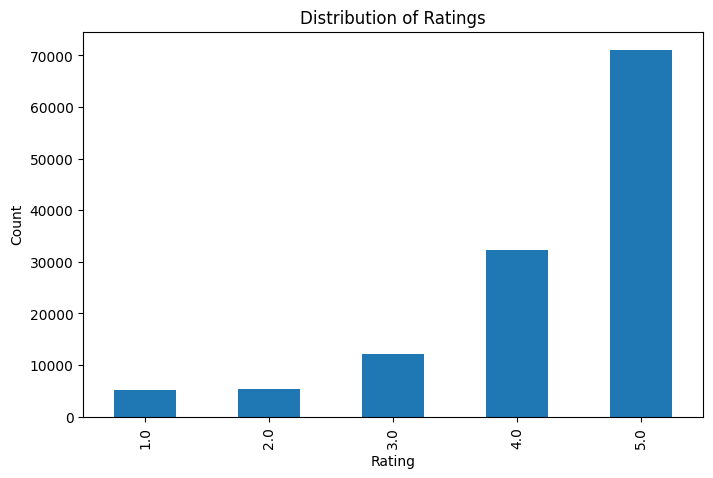

```python
# Create a bar plot for 'ratings'
plt.figure(figsize=(8, 5))
df["rating"].value_counts().sort_index().plot(kind="bar")

# Add labels and title
plt.xlabel("Rating")
plt.ylabel("Count")
plt.title("Distribution of Ratings")

# Show the plot
plt.show()
```

**Observations:**

- This visualization **confirms the positive skew** in the data.

### **Checking the number of unique users and items in the dataset**

```python
# Number of total rows in the data and number of unique user id and product id in the data

# Get total number of rows in the dataset
total_rows = len(df)

# Get the number of unique user IDs and product IDs
unique_users = df["user_id"].nunique()
unique_products = df["prod_id"].nunique()

# Calculate percentages
unique_users_pct = (unique_users / total_rows) * 100
unique_products_pct = (unique_products / total_rows) * 100

# Display results
print(f"Total Rows: {total_rows}")
print(f"Unique Users: {unique_users} ({unique_users_pct:.2f}%)")
print(f"Unique Products: {unique_products} ({unique_products_pct:.2f}%)")
```

```
Total Rows: 125871
Unique Users: 1540 (1.22%)
Unique Products: 48190 (38.29%)
```

**Observations:**

### **Users with the most number of ratings**

```python
# Top 10 users based on the number of ratings
top_users = df["user_id"].value_counts().head(10)

# Convert to DataFrame
top_users_df = top_users.reset_index()
top_users_df.columns = ["user_id", "count"]

# Calculate percentage for each user
top_users_df["percentage"] = (top_users_df["count"] / len(df)) * 100
top_users_df["percentage"] = top_users_df["percentage"].round(2)  # Round to 2 decimal places

# Calculate total contribution of the top 10 users
total_top_10 = top_users_df["count"].sum()
total_top_10_percentage = (total_top_10 / len(df)) * 100
total_top_10_percentage = round(total_top_10_percentage, 2)  # Round to 2 decimal places

# Display results
print(top_users_df)
print(f"\nTotal Top 10 Users' Ratings: {total_top_10} ({total_top_10_percentage}%)")
```

```
          user_id  count  percentage
0   A5JLAU2ARJ0BO    520        0.41
1    ADLVFFE4VBT8    501        0.40
2  A3OXHLG6DIBRW8    498        0.40
3    A6FIAB28IS79    431        0.34
4   A680RUE1FDO8B    406        0.32
5  A1ODOGXEYECQQ8    380        0.30
6  A36K2N527TXXJN    314        0.25
7  A2AY4YUOX2N1BQ    311        0.25
8   AWPODHOB4GFWL    308        0.24
9  A25C2M3QF9G7OQ    296        0.24

Total Top 10 Users' Ratings: 3965 (3.15%)
```

**Observations:**

It's a **strength that the top 10 users contribute only 3.1% of ratings, despite unique users making up just 1.2% of the dataset**.

- Even with filtering, no single group dominates ratings.
- Potential Challenges → New or infrequent users may struggle to receive personalized ratings due to data sparsity from filtering out less active users.

**Now that we have explored and prepared the data, let's build the first recommendation system.**

## **Model 1: Rank Based Recommendation System**

```python
# Compute average rating and rating count in one step
product_stats = df.groupby("prod_id")["rating"].agg(
    avg_rating="mean", rating_count="count"
)

# Sort by average rating in descending order
product_stats = product_stats.sort_values(by="avg_rating", ascending=False)

# Display top 5 records
print(product_stats.head())
```

```
            avg_rating  rating_count
prod_id
B00LKG1MC8         5.0             1
0594451647         5.0             1
B00LGQ6HL8         5.0             5
B00LGN7Y3G         5.0             1
B00L8QCVL6         5.0             1
```

```python
def get_top_products(n: int, min_interactions: int):
    """
    Returns the top n products based on highest average rating,
    considering only products with at least 'min_interactions' ratings.
    """
    return (
        product_stats[product_stats["rating_count"] >= min_interactions]  # Filter first
        .nlargest(n, "avg_rating")  # More efficient than sort + head()
    )
```

### **Recommending top 5 products with 50 minimum interactions based on popularity**

```python
# Get top 5 products with at least 50 interactions
top_5_products = get_top_products(n=5, min_interactions=50)

# Display the top products
print(top_5_products)
```

```
            avg_rating  rating_count
prod_id
B001TH7GUU    4.871795            78
B003ES5ZUU    4.864130           184
B0019EHU8G    4.855556            90
B006W8U2MU    4.824561            57
B000QUUFRW    4.809524            84
```

### **Recommending top 5 products with 100 minimum interactions based on popularity**

```python
# Get top 5 products with at least 50 interactions
top_5_products = get_top_products(n=5, min_interactions=100)

# Display the top products
print(top_5_products)
```

```
            avg_rating  rating_count
prod_id
B003ES5ZUU    4.864130           184
B000N99BBC    4.772455           167
B002WE6D44    4.770000           100
B007WTAJTO    4.701220           164
B002V88HFE    4.698113           106
```

We have recommended the **top 5** products by using the popularity recommendation system. Now, let's build a recommendation system using **collaborative filtering.**

## **Model 2: Collaborative Filtering Recommendation System**

### **Building a baseline user-user similarity based recommendation system**

- Below, we are building **similarity-based recommendation systems** using `cosine` similarity and using **KNN to find similar users** which are the nearest neighbor to the given user.
- We will be using a new library, called `surprise`, to build the remaining models. Let's first import the necessary classes and functions from this library.

**Before building the recommendation systems, let's go over some basic terminologies we are going to use:**

**Relevant item:** An item (product in this case) that is actually **rated higher than the threshold rating** is relevant, if the **actual rating is below the threshold then it is a non-relevant item**.

**Recommended item:** An item that's **predicted rating is higher than the threshold is a recommended item**, if the **predicted rating is below the threshold then that product will not be recommended to the user**.

**False Negative (FN):** It is the **frequency of relevant items that are not recommended to the user**. If the relevant items are not recommended to the user, then the user might not buy the product/item. This would result in the **loss of opportunity for the service provider**, which they would like to minimize.

**False Positive (FP):** It is the **frequency of recommended items that are actually not relevant**. In this case, the recommendation system is not doing a good job of finding and recommending the relevant items to the user. This would result in **loss of resources for the service provider**, which they would also like to minimize.

**Recall:** It is the **fraction of actually relevant items that are recommended to the user**, i.e., if out of 10 relevant products, 6 are recommended to the user then recall is 0.60. Higher the value of recall better is the model. It is one of the metrics to do the performance assessment of classification models.

**Precision:** It is the **fraction of recommended items that are relevant actually**, i.e., if out of 10 recommended items, 6 are found relevant by the user then precision is 0.60. The higher the value of precision better is the model. It is one of the metrics to do the performance assessment of classification models.

**While making a recommendation system, it becomes customary to look at the performance of the model. In terms of how many recommendations are relevant and vice-versa, below are some most used performance metrics used in the assessment of recommendation systems.**

### **Precision@k, Recall@ k, and F1-score@k**

**Precision@k** - It is the **fraction of recommended items that are relevant in `top k` predictions**. The value of k is the number of recommendations to be provided to the user. One can choose a variable number of recommendations to be given to a unique user.

**Recall@k** - It is the **fraction of relevant items that are recommended to the user in `top k` predictions**.

**F1-score@k** - It is the **harmonic mean of Precision@k and Recall@k**. When **precision@k and recall@k both seem to be important** then it is useful to use this metric because it is representative of both of them.

### **Model Utility Functions**

```python
DEFAULT_K = 10  # Default number of recommendations to consider
DEFAULT_THRESHOLD = 3.76  # Minimum rating considered as "relevant"

# Dictionary to store model evaluation results incrementally
model_comparison_results = {}

def precision_recall_at_k(model, model_name, k=DEFAULT_K, threshold=DEFAULT_THRESHOLD):
    """
    Evaluates a recommendation model and stores results **without any output**.

    Parameters:
    - model (Surprise Model): The trained model to evaluate.
    - model_name (str): Name of the model for storage & reference.
    - k (int): Number of recommendations to consider.
    - threshold (float): Minimum rating considered as "relevant."

    Returns:
    - Dictionary of model evaluation results (RMSE, Precision@K, Recall@K, F1-score).

    Updates:
    - Stores results in `model_comparison_results` to avoid redundant computation.
    """

    # Skip evaluation if already stored
    if model_name in model_comparison_results:
        return model_comparison_results[model_name]

    # Generate evaluation predictions
    predictions = model.test(testset)
    rmse_value = accuracy.rmse(predictions, verbose=False)  # No print output

    # Map evaluation predictions to each user
    user_est_true = defaultdict(list)
    for uid, _, true_r, est, _ in predictions:
        user_est_true[uid].append((est, true_r))

    precisions, recalls = {}, {}

    for uid, user_ratings in user_est_true.items():
        user_ratings.sort(key=lambda x: x[0], reverse=True)

        # Compute precision and recall
        n_rel = sum(true_r >= threshold for _, true_r in user_ratings)
        n_rec_k = sum(est >= threshold for est, _ in user_ratings[:k])
        n_rel_and_rec_k = sum((true_r >= threshold and est >= threshold) for est, true_r in user_ratings[:k])

        precisions[uid] = n_rel_and_rec_k / n_rec_k if n_rec_k != 0 else 0
        recalls[uid] = n_rel_and_rec_k / n_rel if n_rel != 0 else 0

    # Compute averages
    precision_avg = round(sum(precisions.values()) / len(precisions), 3)
    recall_avg = round(sum(recalls.values()) / len(recalls), 3)
    f1_score = round((2 * precision_avg * recall_avg) / (precision_avg + recall_avg), 3) if (precision_avg + recall_avg) > 0 else 0

    # Store results
    model_comparison_results[model_name] = {
        "RMSE": rmse_value,
        "Precision@k": precision_avg,
        "Recall@k": recall_avg,
        "F1-score": f1_score
    }

    return model_comparison_results[model_name]
```

```python
def pretty_print_model_evaluations(model_comparison_results):
    """
    Display model evaluation results as a table.

    Parameters:
    - model_comparison_results (dict): Dictionary storing RMSE, Precision@K, Recall@K, and F1-score.
    """
    model_evaluations_df = pd.DataFrame.from_dict(model_comparison_results, orient='index')
    model_evaluations_df = model_evaluations_df.reset_index().rename(columns={'index': 'Model'})

    # Display as a clear table
    display.display(model_evaluations_df)
```

```python
# User who has previously rated this product 5 stars
KNOWN_FIVE_STAR_REVIEWER_ID = "A3LDPF5FMB782Z"

# User who has not rated this product
UNKNOWN_RATING_USER_ID = "A2UOHALGF2X77Q"

# Product being revisited for predictions
TARGET_PRODUCT_ID = "1400501466"

# Map for user-friendly names
USER_ID_MAP = {
    "Known 5-Star Reviewer": KNOWN_FIVE_STAR_REVIEWER_ID,
    "Unrated User": UNKNOWN_RATING_USER_ID
}

# Define known actual rating for the reviewer
ACTUAL_REVISITED_RATING = 5.0  # We know this rating is always 5

# Dictionary to store model predictions for the revisited users & product
user_product_predictions = {}

def store_model_predictions(model_name, user_id, product_id, predicted_rating):
    """
    Stores predicted ratings (and actual rating for known user-product pair) for evaluation.

    Parameters:
    - model_name (str): Name of the model being evaluated.
    - user_id (str): User ID (keeps original constant usage).
    - product_id (str): Product ID for which prediction was made.
    - predicted_rating (float): The predicted rating.

    Updates:
    - user_product_predictions dictionary, building up predictions over time.
    """

    # Initialize model entry if not present
    if model_name not in user_product_predictions:
        user_product_predictions[model_name] = {}

    # Use known actual rating for the revisited user-product pair, otherwise store None
    actual_rating = ACTUAL_REVISITED_RATING if user_id == KNOWN_FIVE_STAR_REVIEWER_ID and product_id == TARGET_PRODUCT_ID else None

    # Store the prediction and actual rating
    user_product_predictions[model_name][(user_id, product_id)] = {
        "predicted": predicted_rating,
        "actual": actual_rating  # Will be 5.0 for revisited user-product pair, None otherwise
    }
```

```python
def pretty_print_predictions(user_product_predictions):
    """
    Display stored predictions for user-product pairs in a structured table.

    Parameters:
    - user_product_predictions (dict): Dictionary storing predictions per model.
    """
    rows = []

    for model, predictions in user_product_predictions.items():
        for (user_id, _), data in predictions.items():  # Ignore Product ID
            # Map user to readable name
            user_name = next((name for name, uid in USER_ID_MAP.items() if uid == user_id), user_id)

            # If the user is the known 5-star reviewer, simply mark them as "Known 5-Star Reviewer"
            if user_id == KNOWN_FIVE_STAR_REVIEWER_ID:
                user_name = "Known 5-Star Reviewer"

            # Extract relevant metadata
            metadata = data["predicted"][4]
            neighbors_used = metadata.get("actual_k", "N/A")  # Number of neighbors if available
            prediction_possible = "T" if not metadata.get("was_impossible", False) else "F"  # Convert to T/F

            rows.append([
                model,
                user_name,  # Clean and concise user-friendly name
                data["predicted"][3],  # Predicted rating
                neighbors_used,  # Number of neighbors used
                prediction_possible  # Whether prediction was possible
            ])

    # Create DataFrame
    predictions_df = pd.DataFrame(rows, columns=["Model", "User", "Predicted Rating", "Neighbors Used", "Prediction Possible"])

    # Display table
    display.display(predictions_df)
```

Below we are loading the **`rating` dataset**, which is a **pandas DataFrame**, into a **different format called `surprise.dataset.DatasetAutoFolds`**, which is required by this library. To do this, we will be **using the classes `Reader` and `Dataset`.**

```python
# Instantiate Reader scale with expected rating scale
reader = Reader(rating_scale=(df['rating'].min(), df['rating'].max()))

# Load the rating dataset
data = Dataset.load_from_df(df[['user_id', 'prod_id', 'rating']], reader)

# Split the data into train and test datasets with a fixed random state
trainset, testset = train_test_split(data, test_size=0.2, random_state=42)
```

Now, we are **ready to build the first baseline similarity-based recommendation system** using the cosine similarity.

### **Building the user-user Similarity-based Recommendation System**

```python
# Store the name for reuse in printing visuals
model_name = "User-User CF (Baseline)"

# Declare the similarity options
sim_options = {
    'name': 'cosine',  # Using cosine similarity
    'user_based': True  # User-User collaborative filtering
}

# Initialize the KNNBasic model using sim_options declared, Verbose=False, and setting random_state=1
user_user_model = KNNBasic(sim_options=sim_options, verbose=False, random_state=1)

# Fit the model on the training data
user_user_model.fit(trainset)

# Compute precision@k, recall@k, and F1 score, store the results
precision_recall_at_k(user_user_model, model_name)
```

```
{'RMSE': 1.1067424491041502,
 'Precision@k': 0.849,
 'Recall@k': 0.71,
 'F1-score': 0.773}
```

```python
# Show model results
pretty_print_model_evaluations(model_comparison_results)
```

|  | Model | RMSE | Precision@k | Recall@k | F1-score |
| --- | --- | --- | --- | --- | --- |
| 0 | User-User CF (Baseline) | 1.106742 | 0.849 | 0.71 | 0.773 |

**Observations:**

- **RMSE: 1.1067** → Predicted ratings deviate by ~1.1 points on average, leaving room for improvement.
- **Precision: 0.849 (84.9%)** → Most recommended products are relevant, showing strong accuracy.
- **Recall: 0.710 (71.0%)** → Retrieves a reasonable number of relevant items but could improve.
- **F1-Score: 0.773 (77.3%)** → Indicates a balanced trade-off between precision and recall.

Let's now **predict rating for a user with `userId=A3LDPF5FMB782Z` and `productId=1400501466`** as shown below. Here the user has already interacted or watched the product with productId '1400501466' and given a rating of 5.

```python
# Predict rating for a sample user with an interacted product
prediction = user_user_model.predict(uid=KNOWN_FIVE_STAR_REVIEWER_ID, iid=TARGET_PRODUCT_ID)
store_model_predictions(model_name, KNOWN_FIVE_STAR_REVIEWER_ID, TARGET_PRODUCT_ID, prediction)
```

```python
# Print our predictions so far
pretty_print_predictions(user_product_predictions)
```

|  | Model | User | Predicted Rating | Neighbors Used | Prediction Possible |
| --- | --- | --- | --- | --- | --- |
| 0 | User-User CF (Baseline) | Known 5-Star Reviewer | 3.333333 | 6 | T |

**Observations:**

- **Predicted: 3.33** | **Actual: 5.0** → Model **underestimated user preference** for this product.
- **Prediction based on 6 similar users (`actual_k = 6`).**
- **Absolute Error: 1.67 (5.0 - 3.33)** → Aligns with overall RMSE (1.1), indicating the model struggles with **strong positive preferences.**

Below is the function to find the **list of users who have not seen the product with product id "1400501466"**.

```python
def n_users_not_interacted_with(n, data, prod_id):
    users_interacted_with_product = set(data[data['prod_id'] == prod_id]['user_id'])
    all_users = set(data['user_id'])
    return list(all_users.difference(users_interacted_with_product))[:n] # where n is the number of elements to get in the list
```

```python
# Find unique user_id where prod_id is not equal to "1400501466"
n_users_not_interacted_with(5, df_final, TARGET_PRODUCT_ID)

# It is not consistently be observed that 'A2UOHALGF2X77Q' is in the first 5.
# Increasing the n elements decreases the ability to spot check.
# Instead, check if explicitly UNKNOWN_RATING_USER_ID has rated TARGET_PRODUCT_ID.
user_has_rated = df_final.loc[
    (df_final['user_id'] == UNKNOWN_RATING_USER_ID) &
    (df_final['prod_id'] == TARGET_PRODUCT_ID)
]

# If the DataFrame is empty, the user has NOT rated the product
user_has_not_rated = user_has_rated.empty

# Print the result
print(user_has_not_rated)  # True means the user has NOT rated it, False means they have
```

```
True
```

- It can be observed from the above statement that **user "A2UOHALGF2X77Q" has not seen the product with productId "1400501466"**

**Below we are predicting rating for `userId=A2UOHALGF2X77Q` and `prod_id=1400501466`.**

```python
# Predict rating for a sample user with a non interacted product
prediction = user_user_model.predict(uid=UNKNOWN_RATING_USER_ID, iid=TARGET_PRODUCT_ID)
store_model_predictions(model_name, UNKNOWN_RATING_USER_ID, TARGET_PRODUCT_ID, prediction)
```

```python
# Print our results so far
pretty_print_predictions(user_product_predictions)
```

|  | Model | User | Predicted Rating | Neighbors Used | Prediction Possible |
| --- | --- | --- | --- | --- | --- |
| 0 | User-User CF (Baseline) | Known 5-Star Reviewer | 3.333333 | 6 | T |
| 1 | User-User CF (Baseline) | Unrated User | 4.002538 | 2 | T |

**Observations**:

- **User A2UOHALGF2X77Q (Unrated User):** Predicted **4.00**, lower than the **5-star actual rating** given by A3LDPF5FMB782Z.
- **User A3LDPF5FMB782Z (Known 5-Star Reviewer):** Predicted **3.33**, showing underestimation of strong preferences.
- **Model Tends toward moderate predictions** rather than extreme values.

### **Improving similarity-based recommendation system by tuning its hyperparameters**

Below, we will be tuning hyperparameters for the `KNNBasic` algorithm. Let's try to understand some of the hyperparameters of the KNNBasic algorithm:

- **k** (int) – The (max) number of neighbors to take into account for aggregation. Default is 40.
- **min_k** (int) – The minimum number of neighbors to take into account for aggregation. If there are not enough neighbors, the prediction is set to the global mean of all ratings. Default is 1.
- **sim_options** (dict) – A dictionary of options for the similarity measure. And there are four similarity measures available in surprise -
  - cosine
  - msd (default)
  - Pearson
  - Pearson baseline

```python
# Set up parameter grid to tune the hyperparameters
param_grid = {
    'k': [20, 30, 40, 50],
    'min_k': [1, 5, 10],
    'sim_options': {
        'name': ['cosine', 'msd', 'pearson', 'pearson_baseline'],
        'user_based': [True]
    }
}

# Perform 3-fold cross-validation to tune the hyperparameters
gs = GridSearchCV(KNNBasic, param_grid, measures=['rmse'], cv=3, n_jobs=-1)

# Fit the data
gs.fit(data)

# Best RMSE score
print("Best RMSE score:", gs.best_score['rmse'])

# Combination of parameters that gave the best RMSE score
best_params = gs.best_params['rmse']
print("Best parameters:", best_params)
```

```
Best RMSE score: 1.0520734092599628
Best parameters: {'k': 50, 'min_k': 5, 'sim_options': {'name': 'cosine', 'user_based': True}}
```

Once the grid search is **complete**, we can get the **optimal values for each of those hyperparameters**.

Now, let's build the **final model by using tuned values of the hyperparameters**, which we received by using **grid search cross-validation**.

```python
model_name = "User-User CF (Hyper-Tuned)"

# Use the optimal similarity measure for user-user collaborative filtering
best_sim_options = best_params['sim_options']  # Extracting the best similarity measure

# Create an instance of KNNBasic with optimal hyperparameter values
user_user_optimized = KNNBasic(
    k=best_params['k'],  # Best k found dynamically
    min_k=best_params['min_k'],  # Best min_k found dynamically
    sim_options=best_sim_options,  # Best similarity measure
    verbose=False
)

# Train the algorithm on the trainset
user_user_optimized.fit(trainset)

# Compute precision@k and recall@k with k=10
precision_recall_at_k(user_user_optimized, model_name)
```

```
{'RMSE': 1.0508478807396044,
 'Precision@k': 0.838,
 'Recall@k': 0.718,
 'F1-score': 0.773}
```

```python
# Compare model results
pretty_print_model_evaluations(model_comparison_results)
```

|  | Model | RMSE | Precision@k | Recall@k | F1-score |
| --- | --- | --- | --- | --- | --- |
| 0 | User-User CF (Baseline) | 1.106742 | 0.849 | 0.710 | 0.773 |
| 1 | User-User CF (Hyper-Tuned) | 1.050848 | 0.838 | 0.718 | 0.773 |

**Observations:**

- **RMSE Improvement**
  - **Baseline: 1.1067 → Tuned: 1.0508** → Clear improvement in prediction accuracy.
- **Precision Changes**
  - **Baseline: 0.849 → Tuned: 0.838** → Slight decrease but still high, meaning recommendations remain relevant.
- **Recall Improvement**
  - **Baseline: 0.710 → Tuned: 0.718** → Slight increase, retrieving more relevant recommendations.
- **F1-Score Stability**
  - **Baseline: 0.773 → Tuned: 0.773** → No major change, indicating precision-recall balance remains stable.

### **Steps:**

- **Predict rating for the user with `userId="A3LDPF5FMB782Z"`, and `prod_id= "1400501466"` using the optimized model**
- **Predict rating for `userId="A2UOHALGF2X77Q"` who has not interacted with `prod_id ="1400501466"`, by using the optimized model**
- **Compare the output with the output from the baseline model**

```python
# Use user_user_optimized model to recommend for userId "A3LDPF5FMB782Z" and productId 1400501466
prediction = user_user_optimized.predict(uid=KNOWN_FIVE_STAR_REVIEWER_ID, iid=TARGET_PRODUCT_ID)
store_model_predictions(model_name, KNOWN_FIVE_STAR_REVIEWER_ID, TARGET_PRODUCT_ID, prediction)
```

```python
# Use user_user_optimized model to recommend for userId "A2UOHALGF2X77Q" and productId "1400501466"
prediction = user_user_optimized.predict(uid=UNKNOWN_RATING_USER_ID, iid=TARGET_PRODUCT_ID)
store_model_predictions(model_name, UNKNOWN_RATING_USER_ID, TARGET_PRODUCT_ID, prediction)
```

```python
# Print our predictions so far
pretty_print_predictions(user_product_predictions)
```

|  | Model | User | Predicted Rating | Neighbors Used | Prediction Possible |
| --- | --- | --- | --- | --- | --- |
| 0 | User-User CF (Baseline) | Known 5-Star Reviewer | 3.333333 | 6 | T |
| 1 | User-User CF (Baseline) | Unrated User | 4.002538 | 2 | T |
| 2 | User-User CF (Hyper-Tuned) | Known 5-Star Reviewer | 3.333333 | 6 | T |
| 3 | User-User CF (Hyper-Tuned) | Unrated User | 4.263417 | N/A | F |

**Observations:**

- **User A3LDPF5FMB782Z (Previously Rated):**
  - **Predicted: 3.33 (Actual: 5.0)** → This model also underestimates.
  - Based on 6 similar users (`actual_k = 6`), but **absolute error (1.67) is higher than expected** given RMSE (1.05).
  - Prediction skews lower than the dataset mean (4.26), suggesting nearby users tend to give more moderate ratings.
- **User A2UOHALGF2X77Q (Unrated):**
  - **Predicted: 4.26 (Actual: N/A)** → **Defaults to dataset mean rating (4.26)** due to lack of strong collaborative signals.
  - **Prediction failed (`was_impossible = True`) due to insufficient neighbors,** reinforcing User-User CF’s weakness with sparse data.

### **Identifying similar users to a given user (nearest neighbors)**

```python
# 0 is the inner id of the above user
# Identify the 5 most similar users to the user with internal ID 0
similar_users = user_user_optimized.get_neighbors(0, k=5)

# Convert internal IDs back to raw user IDs for better readability
similar_users_raw = [trainset.to_raw_uid(user) for user in similar_users]

print(f"Top 5 similar users to user 0: {similar_users_raw}")
```

```
Top 5 similar users to user 0: ['A3OYO7B6SS7QLH', 'A32AK8FOAZEPE2', 'A3F9CBHV4OHFBS', 'A18L9A64XNGVGU', 'A3MQAQT8C6D1I7']
```

### **Implementing the recommendation algorithm based on optimized KNNBasic model**

Below we will be implementing a function where the input parameters are:

- data: A **rating** dataset
- user_id: A user id **against which we want the recommendations**
- top_n: The **number of products we want to recommend**
- algo: the algorithm we want to use **for predicting the ratings**
- The output of the function is a **set of top_n items** recommended for the given user_id based on the given algorithm

```python
def get_recommendations(data, user_id, top_n, algo):
    """Generates top-N recommendations for a given user using the provided model."""

    # Extract products the user has NOT interacted with
    user_item_interactions_matrix = data.pivot(index="user_id", columns="prod_id", values="rating")
    non_interacted_products = user_item_interactions_matrix.loc[user_id][user_item_interactions_matrix.loc[user_id].isnull()].index.tolist()

    # Predict ratings for non-interacted products & sort results
    recommendations = sorted(
        [(item_id, algo.predict(user_id, item_id).est) for item_id in non_interacted_products],
        key=lambda x: x[1], reverse=True
    )

    return recommendations[:top_n]  # Return top N highest predicted ratings
```

**Predicting top 5 products for userId = "A3LDPF5FMB782Z" with similarity based recommendation system**

```python
# Make top 5 recommendations for user_id "A3LDPF5FMB782Z" with a similarity-based recommendation engine
top_5_recommendations = get_recommendations(df, KNOWN_FIVE_STAR_REVIEWER_ID, top_n=5, algo=user_user_optimized)

# Display the recommendations
print(f"Top 5 recommended products for user {KNOWN_FIVE_STAR_REVIEWER_ID}: {top_5_recommendations}")
```

```
Top 5 recommended products for user A3LDPF5FMB782Z: [('B000067RT6', 5.0), ('B00006RVPW', 5.0), ('B0007QQJWA', 5.0), ('B000VX6XL6', 5.0), ('B0012GK3MQ', 5.0)]
```

```python
# Build the dataframe for above recommendations with columns "prod_id" and "predicted_ratings"
recommendations_df = pd.DataFrame(top_5_recommendations, columns=["prod_id", "predicted_ratings"])

# Display the DataFrame
print(recommendations_df)
```

```
      prod_id  predicted_ratings
0  B000067RT6                5.0
1  B00006RVPW                5.0
2  B0007QQJWA                5.0
3  B000VX6XL6                5.0
4  B0012GK3MQ                5.0
```

### **Item-Item Similarity-based Collaborative Filtering Recommendation System**

- Above we have seen **similarity-based collaborative filtering** where similarity is calculated **between users**. Now let us look into similarity-based collaborative filtering where similarity is seen **between items**.

```python
model_name = "Item-Item CF (Baseline)"

# Declare the similarity options for Item-Item CF
sim_options = {
    'name': 'cosine',  # Use cosine similarity
    'user_based': False  # Set to False for Item-Item CF
}

# Initialize KNNBasic algorithm with fixed random state
item_item_model = KNNBasic(sim_options=sim_options, random_state=1)

# Train the algorithm on the trainset
item_item_model.fit(trainset)

# Predict ratings for the test set
predictions = item_item_model.test(testset)

# Compute precision@k, recall@k, and f1-score with k=10
precision_recall_at_k(item_item_model, model_name)
```

```
Computing the cosine similarity matrix...
Done computing similarity matrix.
```

```
{'RMSE': 1.0995351510090863,
 'Precision@k': 0.823,
 'Recall@k': 0.69,
 'F1-score': 0.751}
```

```python
# Compare model results
pretty_print_model_evaluations(model_comparison_results)
```

|  | Model | RMSE | Precision@k | Recall@k | F1-score |
| --- | --- | --- | --- | --- | --- |
| 0 | User-User CF (Baseline) | 1.106742 | 0.849 | 0.710 | 0.773 |
| 1 | User-User CF (Hyper-Tuned) | 1.050848 | 0.838 | 0.718 | 0.773 |
| 2 | Item-Item CF (Baseline) | 1.099535 | 0.823 | 0.690 | 0.751 |

**Observations:**

- **User-User CF (Hyper-Tuned) achieves the lowest RMSE (1.0508),** improving rating accuracy but **F1-score remains unchanged (0.773),** meaning precision-recall balance did not improve.
- **User-User CF (Baseline) has the highest precision (0.849),** suggesting more relevant items but at the cost of higher RMSE.
- **Item-Item CF has better RMSE (1.0995) than User-User CF (Baseline) but sacrifices recall (0.69) and F1-score (0.751),** making it better for accurate individual ratings but less effective for diverse recommendations.
- **User-User CF remains the best choice for personalized recommendations,** whether Baseline or Hyper-Tuned.
- **Item-Item CF may still be useful in sparse data scenarios,** as it recommends products based on product similarity rather than user behavior.

Let's now **predict a rating for a user with `userId = A3LDPF5FMB782Z` and `prod_Id = 1400501466`** as shown below. Here the user has already interacted or watched the product with productId "1400501466".

```python
# Predict rating for a sample user with an interacted product
prediction = item_item_model.predict(uid=KNOWN_FIVE_STAR_REVIEWER_ID, iid=TARGET_PRODUCT_ID)
store_model_predictions(model_name, KNOWN_FIVE_STAR_REVIEWER_ID, TARGET_PRODUCT_ID, prediction)
```

Below we are **predicting rating for the `userId = A2UOHALGF2X77Q` and `prod_id = 1400501466`**.

```python
# Predict rating for a sample user with a non interacted product
prediction = item_item_model.predict(uid=UNKNOWN_RATING_USER_ID, iid=TARGET_PRODUCT_ID)
store_model_predictions(model_name, UNKNOWN_RATING_USER_ID, TARGET_PRODUCT_ID, prediction)
```

```python
# Print our predictions so far
pretty_print_predictions(user_product_predictions)
```

|  | Model | User | Predicted Rating | Neighbors Used | Prediction Possible |
| --- | --- | --- | --- | --- | --- |
| 0 | User-User CF (Baseline) | Known 5-Star Reviewer | 3.333333 | 6 | T |
| 1 | User-User CF (Baseline) | Unrated User | 4.002538 | 2 | T |
| 2 | User-User CF (Hyper-Tuned) | Known 5-Star Reviewer | 3.333333 | 6 | T |
| 3 | User-User CF (Hyper-Tuned) | Unrated User | 4.263417 | N/A | F |
| 4 | Item-Item CF (Baseline) | Known 5-Star Reviewer | 4.250000 | 40 | T |
| 5 | Item-Item CF (Baseline) | Unrated User | 4.500000 | 4 | T |

**Observations**:

- **Item-Item Baseline predicted 4.25 for Known 5-Star Reviewer**, closer to the actual 5.0 than User-User CF (3.33), suggesting item-based similarity better captures user preferences in this case.
- **Item-Item CF successfully provided a prediction**, highlighting a key limitation of User-User CF in sparse data scenarios.
- **For Unrated User (A2UOHALGF2X77Q),** predicted 4.5, the highest among models, exceeding User-User CF Baseline (4.0) and Hyper-Tuned (4.26).
- **Item-Item CF leverages product-based similarities,** meaning users who like one product often like similar ones.
- **Generalizes better for sparse users,** as shown by the increase from 4.0 (User-User Baseline) → 4.5 (Item-Item CF) for A2UOHALGF2X77Q.

### **Hyperparameter tuning the item-item similarity-based model**

- Use the following values for the param_grid and tune the model.
  - 'k': [10, 20, 30]
  - 'min_k': [3, 6, 9]
  - 'sim_options': {'name': ['msd', 'cosine']
  - 'user_based': [False]
- Use GridSearchCV() to tune the model using the 'rmse' measure
- Print the best score and best parameters

```python
# Define parameter grid based on instructions
param_grid = {
    'k': [10, 20, 30],  # Number of neighbors
    'min_k': [3, 6, 9],  # Minimum number of neighbors
    'sim_options': {
        'name': ['msd', 'cosine'],  # Similarity metrics
        'user_based': [False]  # Item-Item CF
    }
}

# Instantiate Reader scale with expected rating scale
reader = Reader(rating_scale=(df['rating'].min(), df['rating'].max()))

# Load df into Surprise Dataset format
surprise_data = Dataset.load_from_df(df[['user_id', 'prod_id', 'rating']], reader)

# Limit n_jobs=2 and reduce cross-validation folds (cv=3 → cv=2)
gs = GridSearchCV(KNNBasic, param_grid, measures=['rmse'], cv=2, n_jobs=2)
gs.fit(surprise_data)

# Print the best RMSE score
print("Best RMSE score:", gs.best_score['rmse'])

# Print the best hyperparameters
best_params = gs.best_params['rmse']
print("Best parameters:", best_params)
```

```
Best RMSE score: 1.0588879567499043
Best parameters: {'k': 30, 'min_k': 6, 'sim_options': {'name': 'msd', 'user_based': False}}
```

Once the **grid search** is complete, we can get the **optimal values for each of those hyperparameters as shown above.**

Now let's build the **final model** by using **tuned values of the hyperparameters** which we received by using grid search cross-validation.

### **Use the best parameters from GridSearchCV to build the optimized item-item similarity-based model. Compare the performance of the optimized model with the baseline model.**

```python
model_name = "Item-Item CF (Hyper-Tuned)"

# Extract best similarity options
best_sim_options = best_params['sim_options']

# Initialize optimized model with best parameters
item_item_optimized = KNNBasic(
    k=best_params['k'],
    min_k=best_params['min_k'],
    sim_options=best_sim_options,
    verbose=False
)

# Train the optimized Item-Item CF model
item_item_optimized.fit(trainset)

# Evaluate the optimized model
precision_recall_at_k(item_item_optimized, model_name)
```

```
{'RMSE': 1.0526209261040929,
 'Precision@k': 0.824,
 'Recall@k': 0.706,
 'F1-score': 0.76}
```

```python
# Compare model results
pretty_print_model_evaluations(model_comparison_results)
```

|  | Model | RMSE | Precision@k | Recall@k | F1-score |
| --- | --- | --- | --- | --- | --- |
| 0 | User-User CF (Baseline) | 1.106742 | 0.849 | 0.710 | 0.773 |
| 1 | User-User CF (Hyper-Tuned) | 1.050848 | 0.838 | 0.718 | 0.773 |
| 2 | Item-Item CF (Baseline) | 1.099535 | 0.823 | 0.690 | 0.751 |
| 3 | Item-Item CF (Hyper-Tuned) | 1.052621 | 0.824 | 0.706 | 0.760 |

**Observations**:

- **RMSE improved significantly** (**1.0995 → 1.0527**), indicating better prediction accuracy.
- **Recall increased** (**0.690 → 0.706**), suggesting **slightly better retrieval of relevant recommendations**.
- **F1-score improved** (**0.751 → 0.760**), meaning **a better balance between precision and recall**.

### **Steps:**

- **Predict rating for the user with `userId="A3LDPF5FMB782Z"`, and `prod_id= "1400501466"` using the optimized model**
- **Predict rating for `userId="A2UOHALGF2X77Q"` who has not interacted with `prod_id ="1400501466"`, by using the optimized model**
- **Compare the output with the output from the baseline model**

```python
# Use item_item_optimized model to make prediction for userId "A3LDPF5FMB782Z" and productId "1400501466"
prediction = item_item_optimized.predict(uid=KNOWN_FIVE_STAR_REVIEWER_ID, iid=TARGET_PRODUCT_ID)
store_model_predictions(model_name, KNOWN_FIVE_STAR_REVIEWER_ID, TARGET_PRODUCT_ID, prediction)
```

```python
# Useitem_item_optimized model to make prediction for userId "A2UOHALGF2X77Q" and productId "1400501466"
prediction = item_item_optimized.predict(uid=UNKNOWN_RATING_USER_ID, iid=TARGET_PRODUCT_ID)
store_model_predictions(model_name, UNKNOWN_RATING_USER_ID, TARGET_PRODUCT_ID, prediction)
```

```python
# Print our predictions so far
pretty_print_predictions(user_product_predictions)
```

|  | Model | User | Predicted Rating | Neighbors Used | Prediction Possible |
| --- | --- | --- | --- | --- | --- |
| 0 | User-User CF (Baseline) | Known 5-Star Reviewer | 3.333333 | 6 | T |
| 1 | User-User CF (Baseline) | Unrated User | 4.002538 | 2 | T |
| 2 | User-User CF (Hyper-Tuned) | Known 5-Star Reviewer | 3.333333 | 6 | T |
| 3 | User-User CF (Hyper-Tuned) | Unrated User | 4.263417 | N/A | F |
| 4 | Item-Item CF (Baseline) | Known 5-Star Reviewer | 4.250000 | 40 | T |
| 5 | Item-Item CF (Baseline) | Unrated User | 4.500000 | 4 | T |
| 6 | Item-Item CF (Hyper-Tuned) | Known 5-Star Reviewer | 4.846154 | 30 | T |
| 7 | Item-Item CF (Hyper-Tuned) | Unrated User | 4.263417 | N/A | F |

### **Identifying similar items to a given item (nearest neighbors)**

```python
# Convert TARGET_PRODUCT_ID to internal Surprise ID
inner_product_id = item_item_optimized.trainset.to_inner_iid(TARGET_PRODUCT_ID)

print(f"Internal ID for product {TARGET_PRODUCT_ID}: {inner_product_id}")
```

```
Internal ID for product 1400501466: 20921
```

```python
# Get the top 5 similar items (nearest neighbors)
similar_items_inner = item_item_optimized.get_neighbors(inner_product_id, k=5)

# Convert internal IDs back to original product IDs
similar_items = [item_item_optimized.trainset.to_raw_iid(iid) for iid in similar_items_inner]

# Print results
print(f"Top 5 similar items to {TARGET_PRODUCT_ID}: {similar_items}")
```

```
Top 5 similar items to 1400501466: ['B000QUUFRW', 'B0051PGX2I', 'B000Q3043Y', 'B0035JCI6M', 'B000UZCR56']
```

**Predicting top 5 products for userId = "A1A5KUIIIHFF4U" with similarity based recommendation system.**

**Hint:** Use the get_recommendations() function.

```python
# Make top 5 recommendations for user_id A1A5KUIIIHFF4U with similarity-based recommendation engine.

# Define the target user
target_user_id = "A1A5KUIIIHFF4U"

# Predict top 5 recommended products using the similarity-based recommendation system
top_5_recommendations = get_recommendations(df, target_user_id, top_n=5, algo=item_item_optimized)

# Display the recommendations
print(f"Top 5 recommended products for user {target_user_id}: {top_5_recommendations}")
```

```
Top 5 recommended products for user A1A5KUIIIHFF4U: [('B00DTZYHX4', 4.565217391304349), ('B0092MD8OW', 4.298245614035087), ('0594451647', 4.263416620322555), ('0594481813', 4.263416620322555), ('0970407998', 4.263416620322555)]
```

```python
# Build the dataframe for above recommendations with columns "prod_id" and "predicted_ratings"
recommendations_df = pd.DataFrame(top_5_recommendations, columns=["prod_id", "predicted_ratings"])
df.head()
```

|  | user_id | prod_id | rating |
| --- | --- | --- | --- |
| 0 | A3BY5KCNQZXV5U | 0594451647 | 5.0 |
| 1 | AT09WGFUM934H | 0594481813 | 3.0 |
| 2 | A32HSNCNPRUMTR | 0970407998 | 1.0 |
| 3 | A17HMM1M7T9PJ1 | 0970407998 | 4.0 |
| 4 | A3CLWR1UUZT6TG | 0972683275 | 5.0 |

Now as we have seen **similarity-based collaborative filtering algorithms**, let us now get into **model-based collaborative filtering algorithms**.

### **Model 3: Model-Based Collaborative Filtering - Matrix Factorization**

Model-based Collaborative Filtering is a **personalized recommendation system**, the recommendations are based on the past behavior of the user and it is not dependent on any additional information. We use **latent features** to find recommendations for each user.

### Singular Value Decomposition (SVD)

SVD is used to **compute the latent features** from the **user-item matrix**. But SVD does not work when we **miss values** in the **user-item matrix**.

```python
model_name = "SVD (Matrix Factorization)"

# Initialize SVD model with fixed random state
svd_model = SVD(random_state=1)

# Train the algorithm on the trainset
svd_model.fit(trainset)

# Evaluate SVD model performance using precision, recall, and RMSE
precision_recall_at_k(svd_model, model_name)
```

```
{'RMSE': 0.9866930309055839,
 'Precision@k': 0.838,
 'Recall@k': 0.671,
 'F1-score': 0.745}
```

```python
# Compare model results
pretty_print_model_evaluations(model_comparison_results)
```

|  | Model | RMSE | Precision@k | Recall@k | F1-score |
| --- | --- | --- | --- | --- | --- |
| 0 | User-User CF (Baseline) | 1.106742 | 0.849 | 0.710 | 0.773 |
| 1 | User-User CF (Hyper-Tuned) | 1.050848 | 0.838 | 0.718 | 0.773 |
| 2 | Item-Item CF (Baseline) | 1.099535 | 0.823 | 0.690 | 0.751 |
| 3 | Item-Item CF (Hyper-Tuned) | 1.052621 | 0.824 | 0.706 | 0.760 |
| 4 | SVD (Matrix Factorization) | 0.986693 | 0.838 | 0.671 | 0.745 |

**Observations**:

- **Lowest RMSE (0.9867)** → Most accurate predictor so far.
- **Precision@k (0.838)** matches User-User CF, showing strong ranking ability.
- **Recall@k (0.671)** is lower than previous models, meaning it retrieves fewer relevant items.
- **F1-score (0.745)** is slightly below Item-Item CF but remains competitive.
- Compared to heuristic-based approaches (User-User & Item-Item CF), SVD better captures user preferences due to lower RMSE.
- Trade-off: Prioritizes precision over recall, meaning it may miss some relevant recommendations.
- User-User CF (Hyper-Tuned) had higher recall (0.718) but much worse RMSE (1.0508 vs. 0.9867).
- This is the best choice so far for accurate rating predictions, but recall could improve.

**Let's now predict the rating for a user with `userId = "A3LDPF5FMB782Z"` and `prod_id = "1400501466`.**

```python
# Use svd model to make prediction for userId "A3LDPF5FMB782Z" and productId "1400501466"
prediction = svd_model.predict(uid=KNOWN_FIVE_STAR_REVIEWER_ID, iid=TARGET_PRODUCT_ID)
store_model_predictions(model_name, KNOWN_FIVE_STAR_REVIEWER_ID, TARGET_PRODUCT_ID, prediction)
```

**Below we are predicting rating for the `userId = "A2UOHALGF2X77Q"` and `productId = "1400501466"`.**

```python
# Use svd model to makep prediction for userId "UNKNOWN_RATING_USER_ID" and productId "1400501466"
prediction = svd_model.predict(uid=UNKNOWN_RATING_USER_ID, iid=TARGET_PRODUCT_ID)
store_model_predictions(model_name, UNKNOWN_RATING_USER_ID, TARGET_PRODUCT_ID, prediction)
```

```python
# Print user predictions
pretty_print_predictions(user_product_predictions)
```

|  | Model | User | Predicted Rating | Neighbors Used | Prediction Possible |
| --- | --- | --- | --- | --- | --- |
| 0 | User-User CF (Baseline) | Known 5-Star Reviewer | 3.333333 | 6 | T |
| 1 | User-User CF (Baseline) | Unrated User | 4.002538 | 2 | T |
| 2 | User-User CF (Hyper-Tuned) | Known 5-Star Reviewer | 3.333333 | 6 | T |
| 3 | User-User CF (Hyper-Tuned) | Unrated User | 4.263417 | N/A | F |
| 4 | Item-Item CF (Baseline) | Known 5-Star Reviewer | 4.250000 | 40 | T |
| 5 | Item-Item CF (Baseline) | Unrated User | 4.500000 | 4 | T |
| 6 | Item-Item CF (Hyper-Tuned) | Known 5-Star Reviewer | 4.846154 | 30 | T |
| 7 | Item-Item CF (Hyper-Tuned) | Unrated User | 4.263417 | N/A | F |
| 8 | SVD (Matrix Factorization) | Known 5-Star Reviewer | 4.113772 | N/A | T |
| 9 | SVD (Matrix Factorization) | Unrated User | 4.066987 | N/A | T |

**Observations**:

- **Introduced matrix factorization**, allowing the model to capture **latent user-product relationships** beyond direct interactions.
- **For Known 5-Star Reviewer:** Predicted **4.1138**, closer to their expected rating than User-User CF (3.33).
- **For Unrated User:** Estimated **4.0669**, providing a prediction even without prior user interactions.
- **Key Strength:** SVD **generalizes better** than User-User CF, as it does not rely on direct neighbor similarities.
- **Key Limitation:** Recall remains slightly lower than Item-Item CF, meaning it may miss some relevant recommendations.

### **Improving Matrix Factorization based recommendation system by tuning its hyperparameters**

Below we will be tuning only three hyperparameters:

- **n_epochs**: The number of iterations of the SGD algorithm.
- **lr_all**: The learning rate for all parameters.
- **reg_all**: The regularization term for all parameters.

```python
# Define the parameter space to tune (matching notebook instructions)
param_grid = {
    'n_epochs': [10, 20, 30],  # Number of iterations of the SGD algorithm
    'lr_all': [0.002, 0.005, 0.01],  # Learning rate for all parameters
    'reg_all': [0.02, 0.05, 0.1]  # Regularization term
}

# Performing 3-fold grid search cross-validation
gs = GridSearchCV(SVD, param_grid, measures=['rmse'], cv=3, n_jobs=-1)

# Fitting the data
gs.fit(data)

# Print best RMSE score
print("Best RMSE score:", gs.best_score['rmse'])

# Print best hyperparameters
best_params = gs.best_params['rmse']
print("Best parameters:", best_params)
```

```
Best RMSE score: 0.9833071704091205
Best parameters: {'n_epochs': 20, 'lr_all': 0.005, 'reg_all': 0.1}
```

Now, we will **the build final model** by using **tuned values** of the hyperparameters, which we received using grid search cross-validation above.

```python
model_name = "SVD (Hyper-Tuned)"

# Build the optimized SVD model using the best hyperparameters
svd_optimized = SVD(
    n_epochs=best_params['n_epochs'],
    lr_all=best_params['lr_all'],
    reg_all=best_params['reg_all'],
    random_state=1  # Ensuring reproducibility
)

# Train the algorithm on the trainset
svd_optimized.fit(trainset)

# Evaluate the optimized SVD model
precision_recall_at_k(svd_optimized, model_name)
```

```
{'RMSE': 0.982911614492803,
 'Precision@k': 0.841,
 'Recall@k': 0.681,
 'F1-score': 0.753}
```

```python
# Compare model results
pretty_print_model_evaluations(model_comparison_results)
```

|  | Model | RMSE | Precision@k | Recall@k | F1-score |
| --- | --- | --- | --- | --- | --- |
| 0 | User-User CF (Baseline) | 1.106742 | 0.849 | 0.710 | 0.773 |
| 1 | User-User CF (Hyper-Tuned) | 1.050848 | 0.838 | 0.718 | 0.773 |
| 2 | Item-Item CF (Baseline) | 1.099535 | 0.823 | 0.690 | 0.751 |
| 3 | Item-Item CF (Hyper-Tuned) | 1.052621 | 0.824 | 0.706 | 0.760 |
| 4 | SVD (Matrix Factorization) | 0.986693 | 0.838 | 0.671 | 0.745 |
| 5 | SVD (Hyper-Tuned) | 0.982912 | 0.841 | 0.681 | 0.753 |

### **Steps:**

- **Predict rating for the user with `userId="A3LDPF5FMB782Z"`, and `prod_id= "1400501466"` using the optimized model**
- **Predict rating for `userId="A2UOHALGF2X77Q"` who has not interacted with `prod_id ="1400501466"`, by using the optimized model**
- **Compare the output with the output from the baseline model**

```python
# Use svd_algo_optimized model to recommend for userId "A3LDPF5FMB782Z" and productId "1400501466"
prediction = svd_optimized.predict(uid=KNOWN_FIVE_STAR_REVIEWER_ID, iid=TARGET_PRODUCT_ID)
store_model_predictions(model_name, KNOWN_FIVE_STAR_REVIEWER_ID, TARGET_PRODUCT_ID, prediction)
```

```python
# Use svd_algo_optimized model to recommend for userId "A3LDPF5FMB782Z" and productId "1400501466"
prediction = svd_optimized.predict(uid=UNKNOWN_RATING_USER_ID, iid=TARGET_PRODUCT_ID)
store_model_predictions(model_name, UNKNOWN_RATING_USER_ID, TARGET_PRODUCT_ID, prediction)
```

```python
# Print user predictions
pretty_print_predictions(user_product_predictions)
```

|  | Model | User | Predicted Rating | Neighbors Used | Prediction Possible |
| --- | --- | --- | --- | --- | --- |
| 0 | User-User CF (Baseline) | Known 5-Star Reviewer | 3.333333 | 6 | T |
| 1 | User-User CF (Baseline) | Unrated User | 4.002538 | 2 | T |
| 2 | User-User CF (Hyper-Tuned) | Known 5-Star Reviewer | 3.333333 | 6 | T |
| 3 | User-User CF (Hyper-Tuned) | Unrated User | 4.263417 | N/A | F |
| 4 | Item-Item CF (Baseline) | Known 5-Star Reviewer | 4.250000 | 40 | T |
| 5 | Item-Item CF (Baseline) | Unrated User | 4.500000 | 4 | T |
| 6 | Item-Item CF (Hyper-Tuned) | Known 5-Star Reviewer | 4.846154 | 30 | T |
| 7 | Item-Item CF (Hyper-Tuned) | Unrated User | 4.263417 | N/A | F |
| 8 | SVD (Matrix Factorization) | Known 5-Star Reviewer | 4.113772 | N/A | T |
| 9 | SVD (Matrix Factorization) | Unrated User | 4.066987 | N/A | T |
| 10 | SVD (Hyper-Tuned) | Known 5-Star Reviewer | 4.014064 | N/A | T |
| 11 | SVD (Hyper-Tuned) | Unrated User | 4.062632 | N/A | T |

### **Conclusion and Recommendations**

#### **Why SVD Over Item-Item CF (Hyper-Tuned)?**

Although **Item-Item CF (Hyper-Tuned) produced closer predictions for some users**, SVD is the better **overall model** because:

1. **SVD minimizes overall error across all users** (lowest RMSE).
2. **SVD generalizes better** – it can **predict ratings for all users**, including those with sparse data.
3. **SVD doesn't rely on neighbors**, avoiding failures like those seen for the Unrated User in Item-Item CF.

#### **Final Takeaways**

- **SVD (Hyper-Tuned) is the strongest standalone model for deployment.**
- **User-User CF may be useful in a hybrid model for cold-start users.**
- **Item-Item CF works well but lacks the same scalability as SVD.**